# STAT585 Lab#2

Team #10

February 20, 2019

### Prerequisite

```r
package_required <- c("ggplot2", "sf", "ggspatial","maps","maptools","rgeos","purrr","tidyverse")
sapply(package_required, require, character.only=TRUE)
```

# 1. Tolkien Middle Earth

[figure not shown]

```r
p <- ggplot() +
  geom_sf(data = read_sf("data/ME-GIS/Coastline2.shp"),
          colour="grey10", fill="grey90") +
  geom_sf(data = read_sf("data/ME-GIS/Rivers19.shp"),
          colour="steelblue", size=0.3) +
  geom_sf(data = read_sf("data/ME-GIS/PrimaryRoads.shp"),
          size = 0.7, colour="grey30") +
  geom_sf(data = read_sf("data/ME-GIS/Cities.shp")) +
  theme_bw()

p <- p +  geom_sf_text(aes(label = Name), data = read_sf("data/ME-GIS/Cities.shp")) +
  annotation_scale() +
  annotation_north_arrow()

print(p)
```

# 2. Australia map

```r
# sf read file
ozbig <- read_sf("data/gadm36_AUS_shp/gadm36_AUS_1.shp")

# thin the number of points used
oz_st <- maptools::thinnedSpatialPoly(
  as(ozbig, "Spatial"), tolerance = 0.1,
  minarea = 0.001, topologyPreserve = TRUE)
oz <- st_as_sf(oz_st)
```

## 2.1 Take a glance

```r
head(oz)
```

```
## Simple feature collection with 6 features and 10 fields
## geometry type:  MULTIPOLYGON
## dimension:      XY
## bbox:           xmin: 122.9617 ymin: -37.50506 xmax: 159.1086 ymax: -10.9702
## epsg (SRID):    4326
## proj4string:    +proj=longlat +datum=WGS84 +no_defs
##   GID_0    NAME_0   GID_1                       NAME_1 VARNAME_1 NL_NAME_1
## 1   AUS Australia AUS.1_1  Ashmore and Cartier Islands      <NA>      <NA>
## 2   AUS Australia AUS.2_1 Australian Capital Territory      <NA>      <NA>
## 3   AUS Australia AUS.3_1  Coral Sea Islands Territory      <NA>      <NA>
## 4   AUS Australia AUS.4_1         Jervis Bay Territory      <NA>      <NA>
## 5   AUS Australia AUS.5_1              New South Wales      <NA>      <NA>
## 6   AUS Australia AUS.6_1           Northern Territory      <NA>      <NA>
##      TYPE_1 ENGTYPE_1 CC_1 HASC_1                       geometry
## 1 Territory Territory   12  AU.AS MULTIPOLYGON (((123.5556 -1...
## 2 Territory Territory    8  AU.AC MULTIPOLYGON (((149.138 -35...
## 3 Territory Territory   11  AU.CR MULTIPOLYGON (((155.5394 -2...
## 4 Territory Territory   10  AU.JB MULTIPOLYGON (((150.7692 -3...
## 5     State     State    1  AU.NS MULTIPOLYGON (((149.9447 -3...
## 6 Territory Territory    7  AU.NT MULTIPOLYGON (((137.0677 -1...
```

```r
oz$geometry[[1]]
```

```
## MULTIPOLYGON (((123.5556 -12.53057, 123.5554 -12.53213, 123.5524 -12.53137, 123.5536 -12.53039, 123.5556 -12.53057)), ((123.0178 -12.25917, 123.0194 -12.26083, 123.0164 -12.26833, 123.0161 -12.25861, 123.0178 -12.25917)), ((122.9669 -12.23972, 122.9711 -12.24361, 122.97 -12.24528, 122.9617 -12.24…
```

```r
is.list(oz$geometry[[1]])
```

```
## [1] TRUE
```

```r
oz$geometry[[1]][[1]]
```

```
## [[1]]
##             x         y
## [1,] 123.5556 -12.53057
## [2,] 123.5554 -12.53213
## [3,] 123.5524 -12.53137
## [4,] 123.5536 -12.53039
## [5,] 123.5556 -12.53057
```

```r
class(oz$geometry[[1]][[1]][[1]])
```

```
## [1] "matrix"
```

- The result of `oz$geometry[[1]]` shows each of element in the `geometry` column is a `MULTIPOLYGON` object containning multiple lists.
- The result of `is.list(oz$geometry[[1]])` shows the `MULTIPOLYGON` object is a `list` object
- The result of `oz$geometry[[1]][[1]]` shows each of this list has one sub-list containing a data with some structure.
- The result of `class(oz$geometry[[1]][[1]][[1]])` shows the data stored in the sub-lists is in `matrix` form.

## 2.2 Solution to extract the geometry infomation

- As identifying the `MULTIPOLYGON` objects are three-level `list` objects, we decide to reshape the objects with method of `purrr::flatten` to remove the top level of indexes.
- Then use `purrr::unnest` to remove the second level.
- To remove the last level, we change the data structure from `list` to `tibble` (or `data.frame`) so that the use of `purrr:unnest` can extract the `x` and `y` in the `matrix` and paste them into two new columns, respectively.

```r
ozplus <- oz %>% select(NAME_1, geometry) %>%
  group_by() %>%
  mutate(coord = geometry %>% map(.f = function(m) flatten(.x=m)),
         region = row_number()) %>%
  unnest

st_geometry(ozplus) <- NULL
ozplus <- ozplus %>% mutate(coord = coord %>% map(.f = function(m) as_tibble(m)),
                            group = row_number()) %>%
  unnest
```

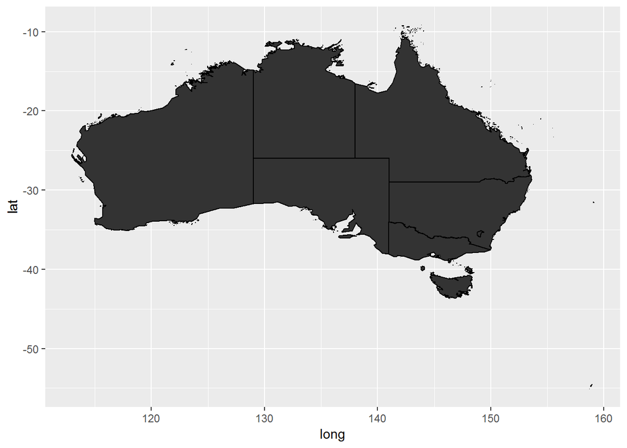

```r
ozplus %>%  setNames(c("name", "region","group", "long", "lat")) %>%
  ggplot(aes(x = long, y = lat, group = group)) + geom_polygon(color = "black")
```